# Análisis espacial del Suicidio en Yucatán

Octubre de 2020

## Introducción

## Suicidio

De acuerdo con datos del INEGI (2018)INEGI (2018). Estadísticas a propósito del día mundial para la prevención del suicidio. https://www.inegi.org.mx/contenidos/saladeprensa/aproposito/2018/suicidios2018_Nal.pdf ., en el año 2016 se presentaron 6,291 casos de suicidio en territorio mexicano, lo que representa una tasa de 5.1 suicidios por cada 100 mil hab. Esta tasa de suicidios varía por cada entidad, siendo Chihuahua y Yucatán los estados con las mayores tasas de suicidio, con 11.4 y 10.2 respectivamente.

A pesar de la complejidad y diversidad de factores que pueden llevar a una persona a cometer suicidio, el evento es prevenible. OMS (2014) World Health Organization (2014). Preventing Suicide: a global imperative. WHO, Switzerland. exhorta a priorizar la prevención del suicidio a nivel mundial a través de un modelo basado en 4 pasos: i) Vigilancia, ii) Identificar factores de riesgo y factores protectores, iii) Desarrollar y evaluar intervenciones y iv) Implementación de políticas y programas.

## Objetivos

*General*

- Caracterizar el Fenómeno del Suicidio en Yucatán en el periodo 2012-2018, desde la perspectiva demográfica y socio-económica, a través de la relación entre la variable dependiente (Tasa de suicidios por municipio) y las variables independientes (Seleccionadas del Censo de Población y Vivienda 2010).

## Hipótesis

Existe una relación entre la tasa de suicidios y las características demográficas y socio-económicas del lugar de ocurrencia.

[figure not shown]

Indicadores:

- Características educativas
- Características económicas
- Servicios de salud
- Discapacidad
- Hogares censales
- Hablantes de lengua indígena, etc.

## Describiendo los datos

## Urbano o rural

Se cuenta con una base de datos de 1146 suicidios ocurridos en Yucatán entre los años 2012-2018, agrupados por municipios (Yucatán cuenta con un total de 106 municipios). A continuación, se muestran algunos gráficos descriptivos.

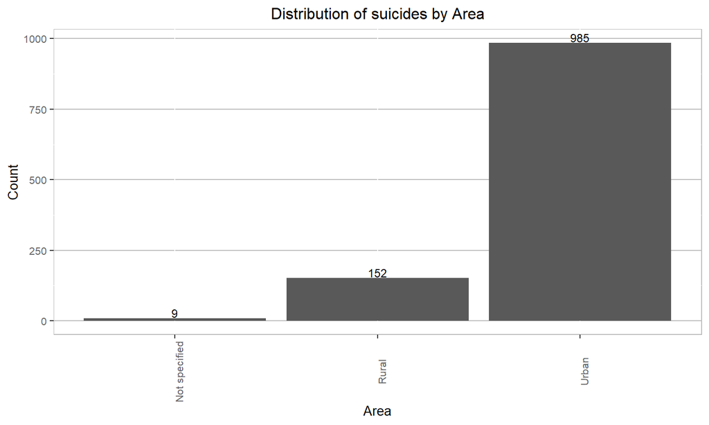

## Método de suicidio

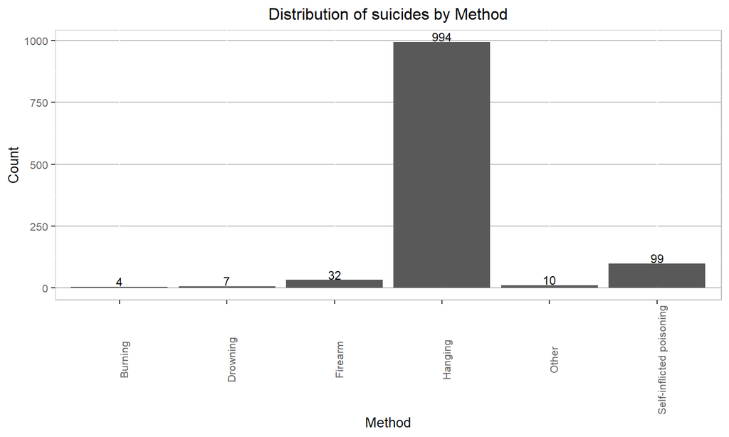

## Edad

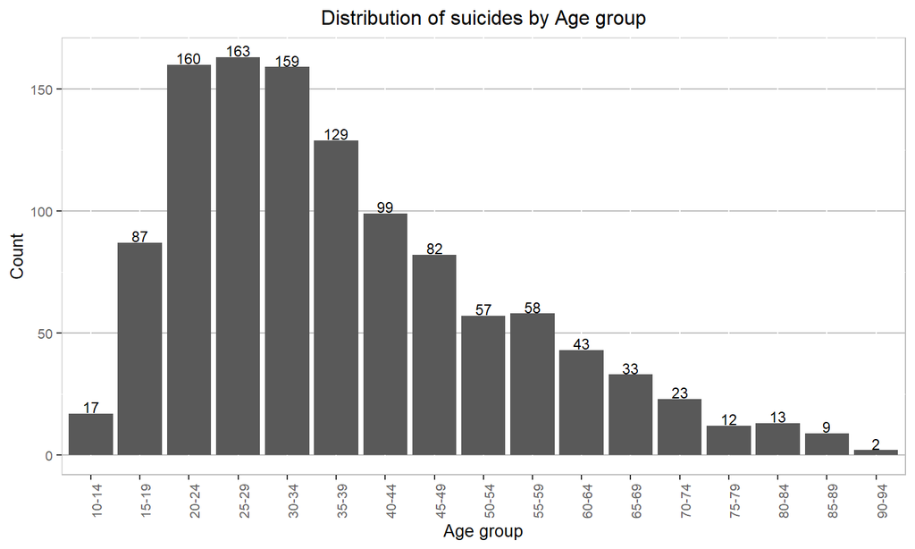

## Mapa de tasa de suicidios

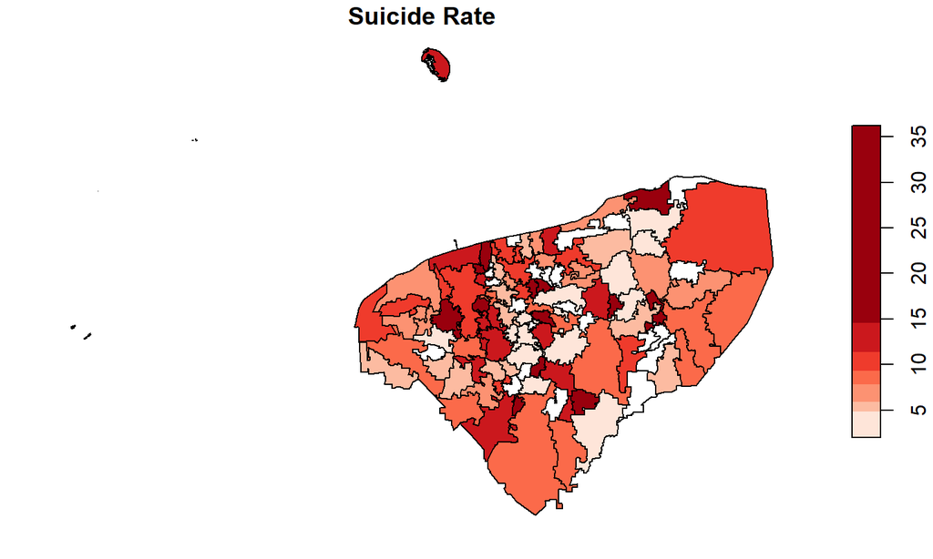

## Tasa de suicidio por municipio

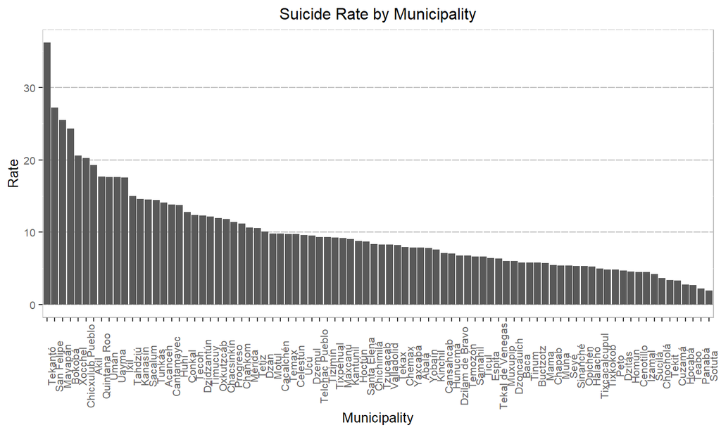

## Histograma de tasas de suicidio

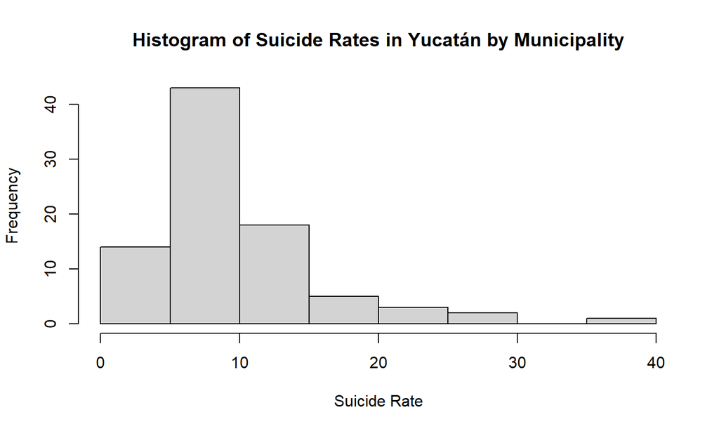